# CP03 PISA

Adrián González Retamosa

9/11/2020

# INDICE

1. Diccionario del Data Set
2. Objetivos del trabajo
3. Analisis y limpieza del Data Set
4. Eleccion grados polinomicos y grados de libertad con Cross Validation
5. Creacion de modelo GAM
6. Prediccion
7. Conclusiones

## 1. Diccionario del Data Set

Overall - Nuestra variable dependiente, la nota media de ciencias

Interest - El interés del alumno por la ciencia

Support - El apoyo a la investigación científica en el país

Income - Ea paridad de poder adquisitvio en dólares de 2005

health - Mide la inversion en sanidad del pais

edu - Mide la inversion en educacion del pais

hdi - El indice de gini del pais

## 2. Objetivos del trabajo

A traves de las diferentes variables construir un modelo GAM que nos permita predecir la nota media de cada detrminado pais en las asignaturas de ciencia.

## 3. Analisis y limpieza del Data Set

Cargamos las librerias necesarias y el data set de trabajo

```r
library(readr)
library(prettydoc)
library(mgcv)
library(glmnet)
library(boot)
library(rsample)
library(car)
library(skimr)
library(janitor)
library(magrittr)
library(imputeTS)
library(tidyverse)
```

```r
setwd('/Users/adrian_gr/Desktop/Data_Science/Prediccion/CP03/data')
df <- read_csv('PISA.csv')
```

## 3. Analisis y limpieza del Data Set

Eliminamos las variables que no vamos a utilizar en nuestro trabajo, armonizamos el estilo de escritiura de las variables y hacemos un resumen estadistico de las variables.

```r
df <- df %>%
  select(-c('Issues', 'Explain', 'Evidence')) #eliminamos las variables que no utilizaremos en el analisis

df %<>% clean_names() #ponemos el nombre de las variables de forma estandar

colnames(df) #observamos los nombres de las variables
```

```
## [1] "country"  "overall"  "interest" "support"  "income"   "health"   "edu"
## [8] "hdi"
```

```r
skim(df) #observamos principales estadisticos y valores NaN
```

Data summary

| Name | df |
| --- | --- |
| Number of rows | 65 |
| Number of columns | 8 |
| _______________________ |  |
| Column type frequency: |  |
| character | 1 |
| numeric | 7 |
| ________________________ |  |
| Group variables | None |

**Variable type: character**

| skim_variable | n_missing | complete_rate | min | max | empty | n_unique | whitespace |
| --- | --- | --- | --- | --- | --- | --- | --- |
| country | 0 | 1 | 4 | 24 | 0 | 65 | 0 |

**Variable type: numeric**

| skim_variable | n_missing | complete_rate | mean | sd | p0 | p25 | p50 | p75 | p100 | hist |
| --- | --- | --- | --- | --- | --- | --- | --- | --- | --- | --- |
| overall | 8 | 0.88 | 473.14 | 54.58 | 322.00 | 428.00 | 489.00 | 513.00 | 563.00 | ▁▃▂▇▅ |
| interest | 8 | 0.88 | 528.16 | 49.84 | 448.00 | 501.00 | 522.00 | 565.00 | 644.00 | ▆▇▅▃▂ |
| support | 8 | 0.88 | 512.18 | 26.08 | 447.00 | 494.00 | 512.00 | 529.00 | 569.00 | ▂▅▇▆▂ |
| income | 4 | 0.94 | 0.74 | 0.11 | 0.41 | 0.66 | 0.76 | 0.83 | 0.94 | ▁▃▇▇▆ |
| health | 4 | 0.94 | 0.89 | 0.07 | 0.72 | 0.84 | 0.89 | 0.94 | 0.99 | ▂▂▇▆▇ |
| edu | 6 | 0.91 | 0.80 | 0.11 | 0.54 | 0.72 | 0.81 | 0.88 | 0.99 | ▂▅▆▇▅ |
| hdi | 6 | 0.91 | 0.81 | 0.09 | 0.58 | 0.75 | 0.82 | 0.88 | 0.94 | ▁▃▇▇▇ |

Sustituyo los NaN por la media de cada variable

```r
df %<>% na_mean() #con esta funcion convertimos los valores NaN en la media de ese regresor
```

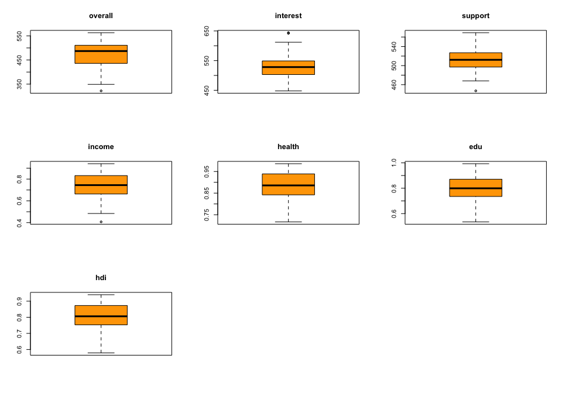

```r
df_n <- df %>%
  select(!'country') #eliminamos la variable categorica

par(mfrow=c(3,3))

for (i in 1:7) {
  boxplot(df_n[,i], main=colnames(df_n)[i], type = "l", col="orange")
  abline(h=0, lty=2, lwd=1.5)
}

par(mfrow=c(1,1))
```

Realizamos un grafico de dispersion para comprobar como es la relacion entre los regresores y la variable dependiente.

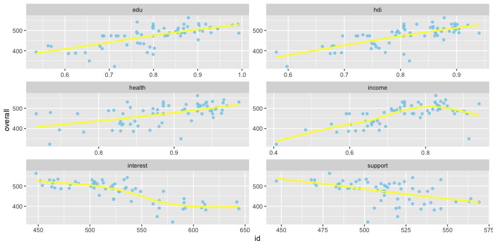

```r
df %>% tidyr::gather(key = 'regresor', value = 'id', 3:8) %>%
  ggplot(aes(x = id, y = overall)) +
  geom_point(color = 'skyblue', alpha = 0.85) +

  geom_smooth(method = 'gam',
              se = FALSE,
              color = 'yellow') +

  facet_wrap(~regresor, ncol = 2, scales = 'free')
```

Analizamos la multicolinealidad entre los regresores.

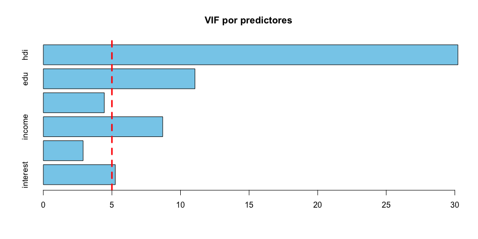

```r
#detectar multicolinealidad a partir del factor de inflacion de la varianza en las variables numericas
model  <- lm(overall ~ ., data = df_n)
vif_valores <- car::vif(model)
barplot(vif_valores,
        main = "VIF por predictores",
        horiz = TRUE,
        col = "skyblue")
abline(v = 5, lwd = 3, lty = 2, col = "red") # linea indicadora de problemas de VIF
```

```r
kableExtra::kable(vif_valores)
```

|  | x |
| --- | --- |
| interest | 5.244452 |
| support | 2.900267 |
| income | 8.703616 |
| health | 4.441049 |
| edu | 11.053957 |
| hdi | 30.226489 |

Observamos que hay algunas variables que superan el valor 5 por lo que vamos a dejar fuera del modelo a las variables income, educ y health ya que estan incluidas en hdi. Comprobamos que con este modelo no habria problemas de multicolinealidad.

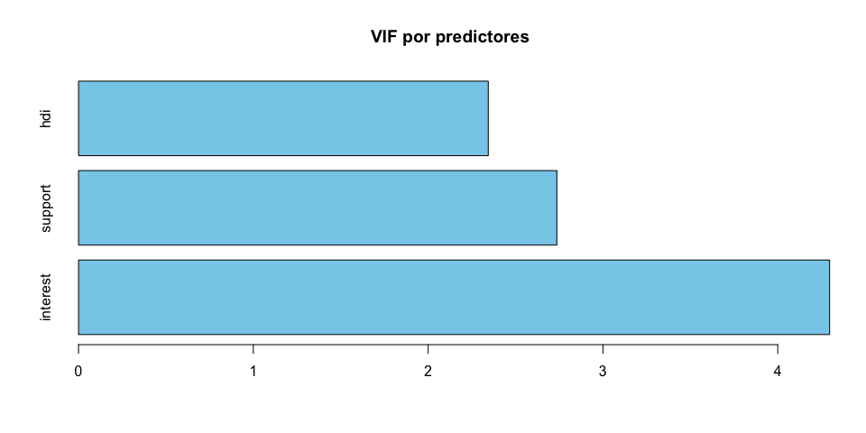

```r
df_hdi <- df %>%
  select('overall' ,'interest', 'support', 'hdi')
model2  <- lm(overall ~ ., data = df_hdi)
vif_valores2 <- car::vif(model2)
barplot(vif_valores2,
        main = "VIF por predictores",
        horiz = TRUE,
        col = "skyblue")
abline(v = 5, lwd = 3, lty = 2, col = "red") # linea indicadora de problemas de VIF
```

```r
kableExtra::kable(vif_valores2)
```

|  | x |
| --- | --- |
| interest | 4.296661 |
| support | 2.736374 |
| hdi | 2.343949 |

## 4. Eleccion grados polinomicos y grados de libertad con Cross Validation

A traves del cross validation calculamos cual seria el grado optimo para la variable income que como se observo en el grafico de dispersion puede no ser lienal.

```r
#hacemos cross validation para averiguar el grado del polinomio en el regresor income que menos error genera
set.seed(891) #aleatoriedad
error_cv <- data.frame(grado=seq(1,7,1),
                        error= rep(NA, 7)) #creamos un df para ir gurdardo los errores medio de cada polinomio

for (i in 1:7) {
  glm.fit <- glm(overall ~ poly(income, i), data=df)
  error_cv$error[i] <- cv.glm(df, glm.fit, K=11)$delta[1]
}
knitr::kable(error_cv) #observamos que el polinomio que menor error genera es el de grado 2
```

| grado | error |
| --- | --- |
| 1 | 1600.700 |
| 2 | 1460.947 |
| 3 | 2290.830 |
| 4 | 2289.680 |
| 5 | 5084.890 |
| 6 | 21585.338 |
| 7 | 87356.680 |

En este grafico observamos como el error minimo se encontraria en el polinomio de segundo grado

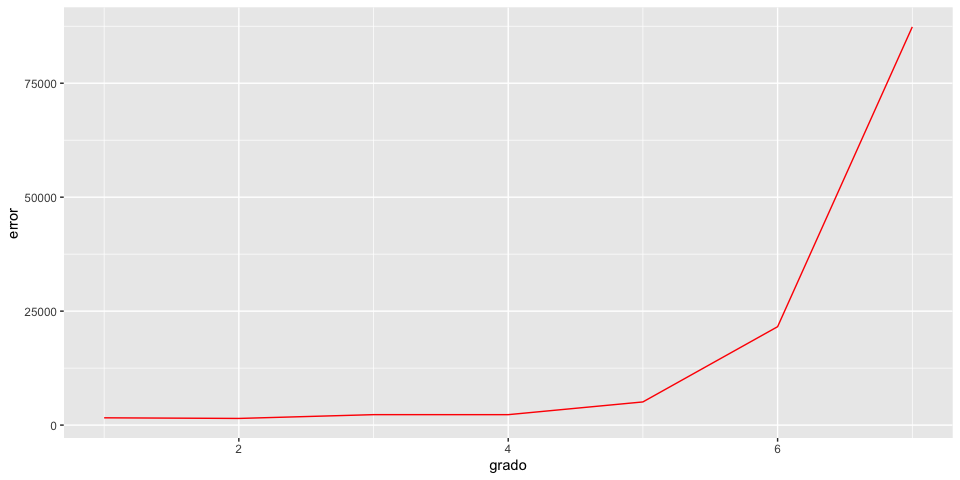

```r
ggplot(error_cv, aes(x = grado, y = error)) +
  geom_line( col = 'red' )
```

Utilizamos tambien el cross validation para encontrar el grado de libertad optimo para cada variable y los almacenamos en una tabla.

```r
attach(df)
gl_interest <- smooth.spline(interest, overall)
gl_support <- smooth.spline(support, overall)
gl_income <- smooth.spline(income, overall)
gl_health <- smooth.spline(health, overall)
gl_edu <- smooth.spline(edu, overall)
gl_hdi <- smooth.spline(hdi, overall)
df_opt <- rbind(gl_interest$df, gl_support$df, gl_income$df, gl_health$df, gl_edu$df, gl_hdi$df )

regresor = colnames(df[3:8])
df_optimo <- as.data.frame(cbind(regresor, df_opt))

knitr::kable(df_optimo)
```

| regresor | V2 |
| --- | --- |
| interest | 23.2480092317535 |
| support | 2.00124330895837 |
| income | 11.2722055033549 |
| health | 2.00284536461907 |
| edu | 2.00238556021777 |
| hdi | 11.1153059604407 |

## 5. Creacion de modelo GAM

Creamos una muestra de entrenamiento y de test para poder comparar las predicciones de nuestros modelos

```r
set.seed(891)
df_split <- initial_split(df_n,
                           prop = 0.85,
                           strata = overall)
df_train <- training(df_split)
df_test <- testing(df_split)
```

Generamos el primer modelo GAM con todos los regresores con splines.

```r
#estimo el primer modelo gam con splines en todos los regresores
gam_1 <- gam(overall ~ s(interest) + s(support) + s(income) + s(health) + s(edu) + s(hdi), data = df_train)
summary(gam_1)
```

```
##
## Family: gaussian
## Link function: identity
##
## Formula:
## overall ~ s(interest) + s(support) + s(income) + s(health) +
##     s(edu) + s(hdi)
##
## Parametric coefficients:
##             Estimate Std. Error t value Pr(>|t|)
## (Intercept)  475.431      2.908   163.5   <2e-16 ***
## ---
## Signif. codes:  0 '***' 0.001 '**' 0.01 '*' 0.05 '.' 0.1 ' ' 1
##
## Approximate significance of smooth terms:
##               edf Ref.df     F  p-value
## s(interest) 5.746  6.840 7.501 4.56e-06 ***
## s(support)  2.371  3.045 3.513   0.0227 *
## s(income)   3.264  4.079 2.413   0.0637 .
## s(health)   1.000  1.000 1.183   0.2831
## s(edu)      1.000  1.000 1.203   0.2791
## s(hdi)      1.000  1.000 2.112   0.1537
## ---
## Signif. codes:  0 '***' 0.001 '**' 0.01 '*' 0.05 '.' 0.1 ' ' 1
##
## R-sq.(adj) =  0.802   Deviance explained = 85.4%
## GCV = 653.03  Scale est. = 473.66    n = 56
```

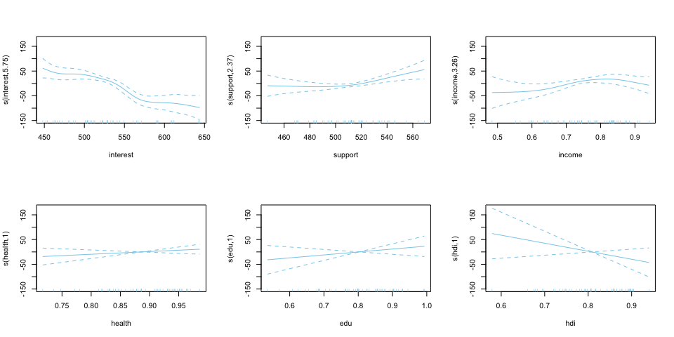

```r
par(mfrow = c(2,3))
plot(gam_1, se=T, col='skyblue') #interest suppor y health
```

En el grafico anterior observamos que hay variables que puede que sea mejor meter en el modelo sin splines y es lo que hacemos en este segundo modelo. Este modelo explica el 85,7% de la varinza de la variable dependiente.

```r
gam_2 <- gam(overall ~ interest + support + s(income) + health + s(edu) + s(hdi), data = df_train)
summary(gam_2)
```

```
##
## Family: gaussian
## Link function: identity
##
## Formula:
## overall ~ interest + support + s(income) + health + s(edu) +
##     s(hdi)
##
## Parametric coefficients:
##             Estimate Std. Error t value Pr(>|t|)
## (Intercept) 464.1570   129.4510   3.586 0.000955 ***
## interest     -0.5279     0.2072  -2.548 0.015071 *
## support       0.3397     0.2738   1.241 0.222391
## health      131.2997   110.5602   1.188 0.242460
## ---
## Signif. codes:  0 '***' 0.001 '**' 0.01 '*' 0.05 '.' 0.1 ' ' 1
##
## Approximate significance of smooth terms:
##             edf Ref.df     F p-value
## s(income) 7.403  8.295 3.418 0.00444 **
## s(edu)    6.071  7.113 2.093 0.07850 .
## s(hdi)    1.000  1.000 7.651 0.00867 **
## ---
## Signif. codes:  0 '***' 0.001 '**' 0.01 '*' 0.05 '.' 0.1 ' ' 1
##
## R-sq.(adj) =   0.79   Deviance explained = 85.7%
## GCV = 749.03  Scale est. = 501.92    n = 56
```

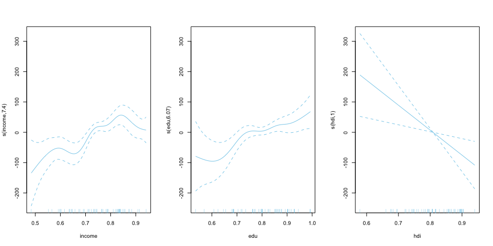

```r
par(mfrow = c(1,3))
plot(gam_2, se=T, col='skyblue')
```

Por ultimo, vamos a correr otro modelo en el cual solo aparezaca la variable hdi, ya que engloba a las variables educ, health e income.

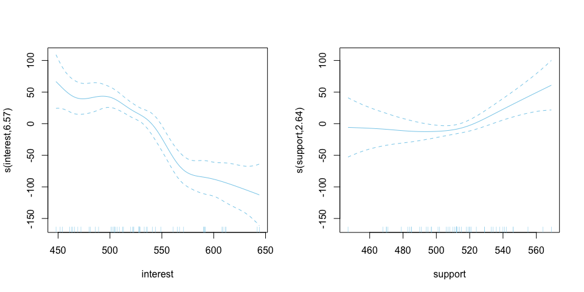

```r
gam_hdi <- gam(overall ~ s(interest) + s(support)  + hdi, data = df_train)

par(mfrow = c(1,2))
plot(gam_hdi, se=T, col='skyblue')
```

```r
summary(gam_hdi)
```

```
##
## Family: gaussian
## Link function: identity
##
## Formula:
## overall ~ s(interest) + s(support) + hdi
##
## Parametric coefficients:
##             Estimate Std. Error t value Pr(>|t|)
## (Intercept)   447.37      54.83   8.159  2.1e-10 ***
## hdi            34.70      67.71   0.512    0.611
## ---
## Signif. codes:  0 '***' 0.001 '**' 0.01 '*' 0.05 '.' 0.1 ' ' 1
##
## Approximate significance of smooth terms:
##               edf Ref.df     F  p-value
## s(interest) 6.571  7.670 9.569 2.01e-08 ***
## s(support)  2.636  3.389 3.639   0.0155 *
## ---
## Signif. codes:  0 '***' 0.001 '**' 0.01 '*' 0.05 '.' 0.1 ' ' 1
##
## R-sq.(adj) =  0.774   Deviance explained = 81.6%
## GCV =  675.2  Scale est. = 540.07    n = 56
```

## 6. Prediccion

Construimos una table donde observamos los valores reales y las predicciones para la muestra de test de los 3 modelos construidos.

```r
pre_gam1 <- predict(gam_1, df_test)
pre_gam2 <- predict(gam_2, df_test)
pre_hdi <- predict(gam_hdi, df_test)

df_pre <- df_test %>%
  select(overall)  %>%
  mutate(pre_gam1 = pre_gam1,
         pre_gam2 = pre_gam2,
         pre_hdi = pre_hdi)

knitr::kable(df_pre)
```

| overall | pre_gam1 | pre_gam2 | pre_hdi |
| --- | --- | --- | --- |
| 527 | 515.2680 | 529.8546 | 509.7141 |
| 510 | 504.1178 | 510.6167 | 505.4073 |
| 434 | 491.6945 | 456.2149 | 498.4808 |
| 322 | 392.3967 | 361.7540 | 374.8476 |
| 486 | 487.5421 | 471.7430 | 504.7594 |
| 511 | 501.9440 | 503.8203 | 492.4087 |
| 488 | 501.2500 | 492.8483 | 494.2160 |
| 424 | 515.7683 | 436.9656 | 524.2589 |
| 428 | 397.3090 | 427.7025 | 396.9178 |

Creamos otra tabla deonde podemos observar que es el segundo modelo, overall + interest + support + s(income) + health + s(edu) + s(hdi), es el que claramente tiene menor error de prediccion.

```r
attach(df_pre)

#GAM_1
gam_1_e <- rbind(mean(abs(pre_gam1 - overall )), sd(abs(pre_gam1 - overall )) )

#GAM_2
gam_2_e <- rbind(mean(abs(pre_gam2 - overall )), sd(abs(pre_gam2 - overall )))

#GAM_hdi
gam_hdi_e <- rbind(mean(abs(pre_hdi - overall )), sd(abs(pre_hdi - overall )))

errores_pred <- data.frame(gam1 = gam_1_e,
                           gam2 = gam_2_e,
                           gam_hdi = gam_hdi_e)

knitr::kable(errores_pred)
```

| gam1 | gam2 | gam_hdi |
| --- | --- | --- |
| 32.44586 | 11.66537 | 34.90165 |
| 32.79728 | 12.76811 | 31.74420 |

## 7. Conclusion

Despues de anlizar la relacion de cada uno de los regresores con la variable dependiente y correr 3 modelos GAM diferentes observamos que el modelo overall = interest + support + s(income) + health + s(edu) + s(hdi) es el que menor error de prediccion tiene.